# Logistic Regression Demonstration

James King

2024-01-14

# Dataset Exploration

```r
# Read in census data
c_train <- read_csv("adult.csv")
c_test <- read_csv("adult.test.csv")
# Convert character columns to factor type
c_train <- c_train %>%
  mutate(
    age = as.factor(age),
    workclass = as.factor(workclass),
    education = as.factor(education),
    education_yrs = as.factor(education_yrs),
    marital_status = as.factor(marital_status),
    occupation = as.factor(occupation),
    relationship = as.factor(relationship),
    race = as.factor(race),
    sex = as.factor(sex),
    native_country = as.factor(native_country),
    income = as.factor(income)
  )

glimpse(c_train)
```

```
## Rows: 32,560
## Columns: 15
## $ age            <fct> 39, 50, 38, 53, 28, 37, 49, 52, 31, 42, 37, 30, 23, 32,…
## $ workclass      <fct> State-gov, Self-emp-not-inc, Private, Private, Private,…
## $ fnlwgt         <dbl> 77516, 83311, 215646, 234721, 338409, 284582, 160187, 2…
## $ education      <fct> Bachelors, Bachelors, HS-grad, 11th, Bachelors, Masters…
## $ education_yrs  <fct> 13, 13, 9, 7, 13, 14, 5, 9, 14, 13, 10, 13, 13, 12, 11,…
## $ marital_status <fct> Never-married, Married-civ-spouse, Divorced, Married-ci…
## $ occupation     <fct> Adm-clerical, Exec-managerial, Handlers-cleaners, Handl…
## $ relationship   <fct> Not-in-family, Husband, Not-in-family, Husband, Wife, W…
## $ race           <fct> White, White, White, Black, Black, White, Black, White,…
## $ sex            <fct> Male, Male, Male, Male, Female, Female, Female, Male, F…
## $ capital_gain   <dbl> 2174, 0, 0, 0, 0, 0, 0, 0, 14084, 5178, 0, 0, 0, 0, 0, …
## $ capital_loss   <dbl> 0, 0, 0, 0, 0, 0, 0, 0, 0, 0, 0, 0, 0, 0, 0, 0, 0, 0, 0…
## $ hours_per_week <dbl> 40, 13, 40, 40, 40, 40, 16, 45, 50, 40, 80, 40, 30, 50,…
## $ native_country <fct> United-States, United-States, United-States, United-Sta…
## $ income         <fct> <=50K, <=50K, <=50K, <=50K, <=50K, <=50K, <=50K, >50K, …
```

```r
c_test <- c_test %>%
  mutate(
    age = as.factor(age),
    workclass = as.factor(workclass),
    education = as.factor(education),
    education_yrs = as.factor(education_yrs),
    marital_status = as.factor(marital_status),
    occupation = as.factor(occupation),
    relationship = as.factor(relationship),
    race = as.factor(race),
    sex = as.factor(sex),
    native_country = as.factor(native_country),
    income = as.factor(income)
  )

glimpse(c_test)
```

```
## Rows: 16,281
## Columns: 15
## $ age            <fct> 25, 38, 28, 44, 18, 34, 29, 63, 24, 55, 65, 36, 26, 58,…
## $ workclass      <fct> Private, Private, Local-gov, Private, ?, Private, ?, Se…
## $ fnlwgt         <dbl> 226802, 89814, 336951, 160323, 103497, 198693, 227026, …
## $ education      <fct> 11th, HS-grad, Assoc-acdm, Some-college, Some-college, …
## $ education_yrs  <fct> 7, 9, 12, 10, 10, 6, 9, 15, 10, 4, 9, 13, 9, 9, 9, 14, …
## $ marital_status <fct> Never-married, Married-civ-spouse, Married-civ-spouse, …
## $ occupation     <fct> Machine-op-inspct, Farming-fishing, Protective-serv, Ma…
## $ relationship   <fct> Own-child, Husband, Husband, Husband, Own-child, Not-in…
## $ race           <fct> Black, White, White, Black, White, White, Black, White,…
## $ sex            <fct> Male, Male, Male, Male, Female, Male, Male, Male, Femal…
## $ capital_gain   <dbl> 0, 0, 0, 7688, 0, 0, 0, 3103, 0, 0, 6418, 0, 0, 0, 3103…
## $ capital_loss   <dbl> 0, 0, 0, 0, 0, 0, 0, 0, 0, 0, 0, 0, 0, 0, 0, 0, 0, 0, 0…
## $ hours_per_week <dbl> 40, 50, 40, 40, 30, 30, 40, 32, 40, 10, 40, 40, 39, 35,…
## $ native_country <fct> United-States, United-States, United-States, United-Sta…
## $ income         <fct> <=50K, <=50K, >50K, >50K, <=50K, <=50K, <=50K, >50K, <=…
```

The data types appear to be appropriate for all the variables.

```r
# Check for NA values
c_train %>%
  summarise_all(~sum(is.na(.)))
```

| age | workclass | fnlwgt | education | education_yrs | marital_status | occupation | relationship | race | sex | capital_gain | capital_loss | hours_per_week | native_country | income |
| --- | --- | --- | --- | --- | --- | --- | --- | --- | --- | --- | --- | --- | --- | --- |
| 0 | 0 | 0 | 0 | 0 | 0 | 0 | 0 | 0 | 0 | 0 | 0 | 0 | 0 | 0 |

```r
c_test %>%
  summarise_all(~sum(is.na(.)))
```

| age | workclass | fnlwgt | education | education_yrs | marital_status | occupation | relationship | race | sex | capital_gain | capital_loss | hours_per_week | native_country | income |
| --- | --- | --- | --- | --- | --- | --- | --- | --- | --- | --- | --- | --- | --- | --- |
| 0 | 0 | 0 | 0 | 0 | 0 | 0 | 0 | 0 | 0 | 0 | 0 | 0 | 0 | 0 |

There are no NA values to control for. If there were NA values, I would likely omit them since the dataset is large enough to do so without losing value.

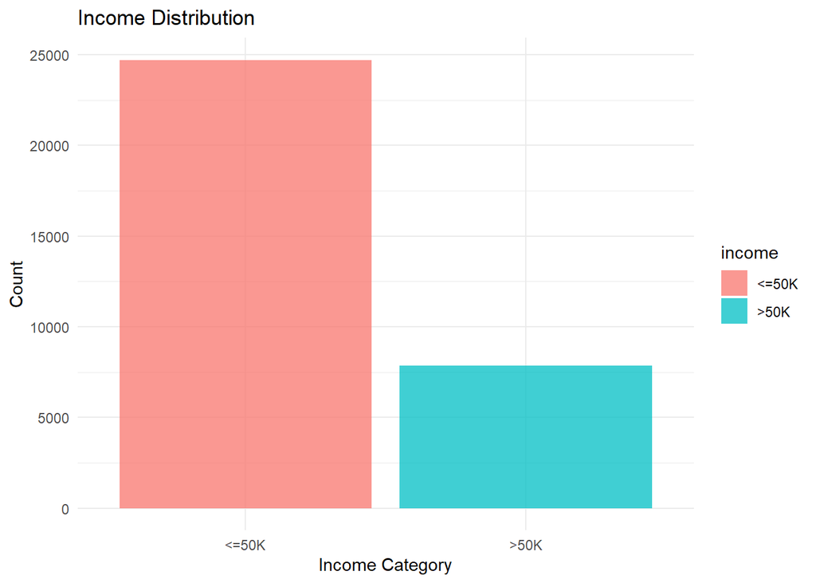

```r
# Plot response variable distribution
ggplot(c_train, aes(x = income, fill = income)) +
  geom_bar(alpha = 0.75) +
  labs(title = "Income Distribution", x = "Income Category", y = "Count") +
  theme_minimal()
```

The data are imbalanced, however the sampling was representative of the population, so this should not be a problem. Also to note, “<=50K” is the first and most common level, which is what we want for modeling. Two ways to manage imbalanced data might be: down sampling or adjusting the decision threshold in the logistic regression model if deemed necessary.

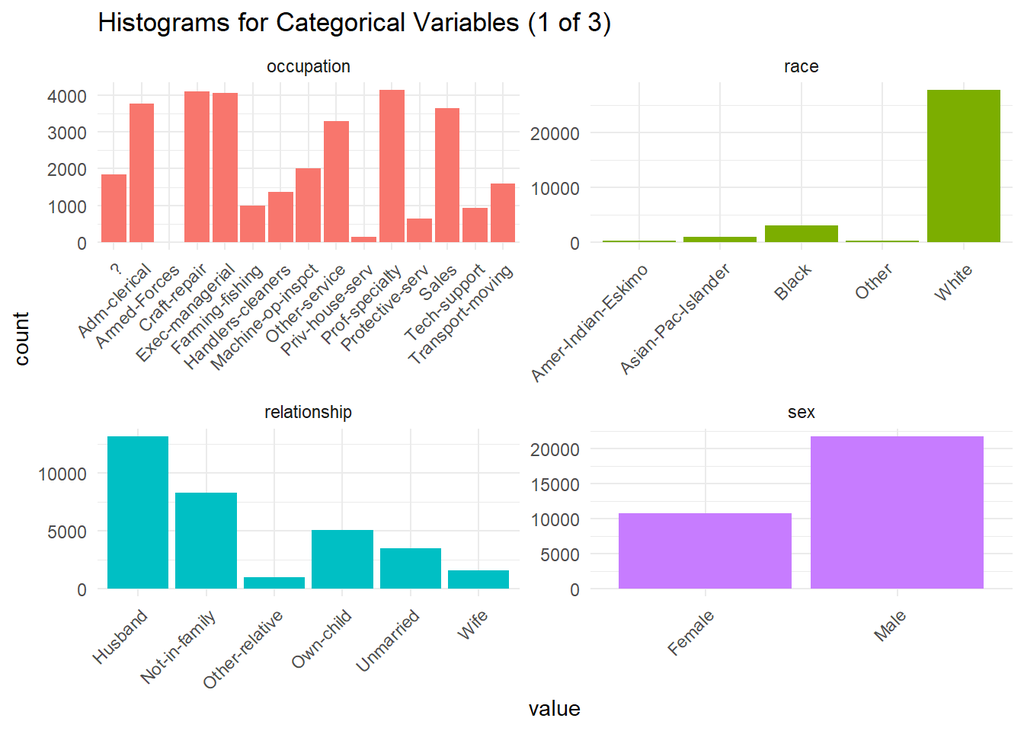

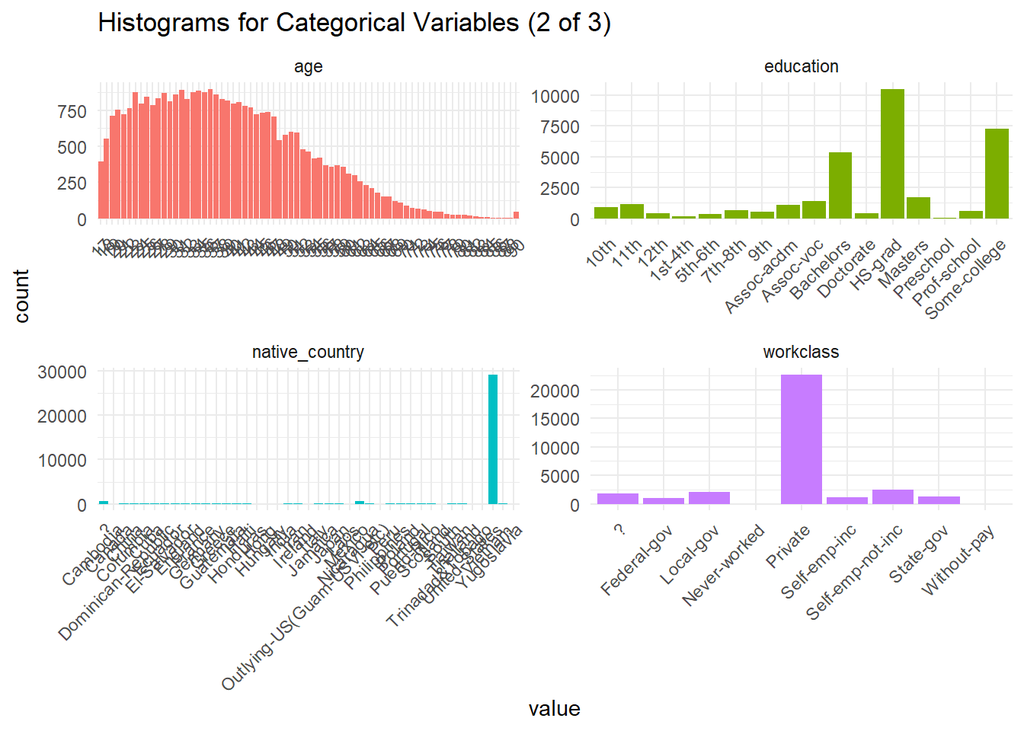

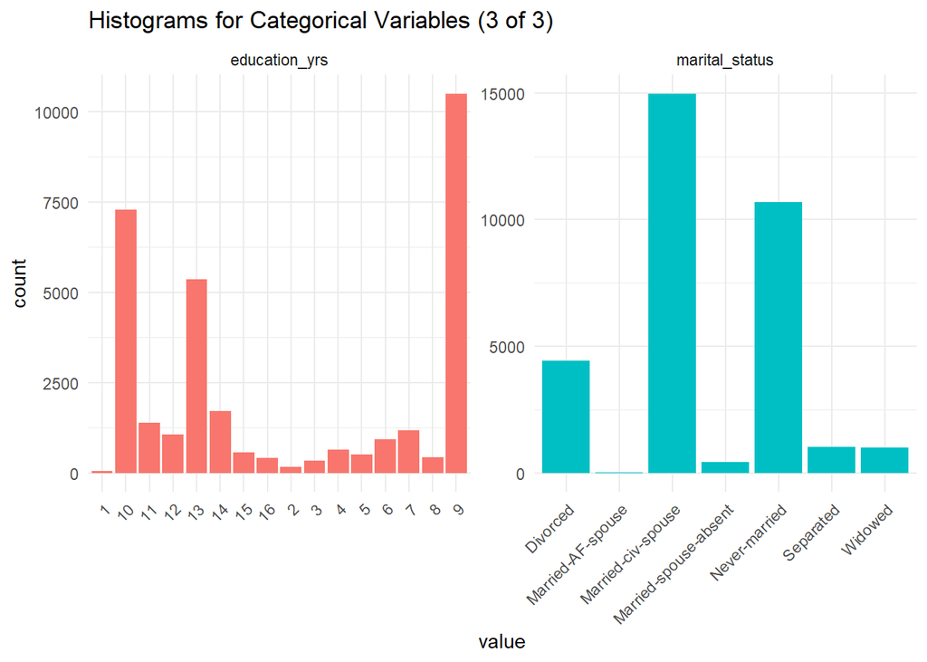

```r
# Examine data
# Specify categorical columns
cat_columns <- list(
  c("occupation", "relationship", "race", "sex"),
  c("native_country", "age", "workclass", "education"),
  c("education_yrs", "marital_status")
)

# Function to create histograms
create_histograms <- function(cat_data, title) {
  cat_long <- gather(c_train, key = "variable", value = "value", cat_data)

  ggplot(cat_long, aes(x = value, fill = variable)) +
    geom_histogram(position = "identity", stat = "count") +
    facet_wrap(~variable, scales = "free") +
    labs(title = title) +
    theme_minimal() +
    scale_x_discrete(guide = guide_axis(angle = 45)) +
    guides(fill = FALSE)
}

# Create histograms for each set of categorical columns
for (i in seq_along(cat_columns)) {
  title <- paste("Histograms for Categorical Variables (", i, " of 3)", sep = "")
  plot_output <- create_histograms(cat_columns[[i]], title)
  print(plot_output)
}
```

Age values are mostly concentrated within the working range, so I won’t omit young or old subjects. summary(c_train$age) Min. 1st Qu. Median Mean 3rd Qu. Max. 17.00 28.00 37.00 38.77 48.00 90.00

`native_country` is highly skewed, `race` is skewed, however the rest of the variables seem okay. I will keep this in mind in case I see a need to manage the skewness by examining the residuals plots during model diagnostics.

```r
# Examine the independent variables
cont_columns <- c("fnlwgt", "capital_gain", "capital_loss", "hours_per_week")

# Reshape the data to long format using tidyr
cont_long <- gather(c_train, key = "variable", value = "value", cont_columns)
```

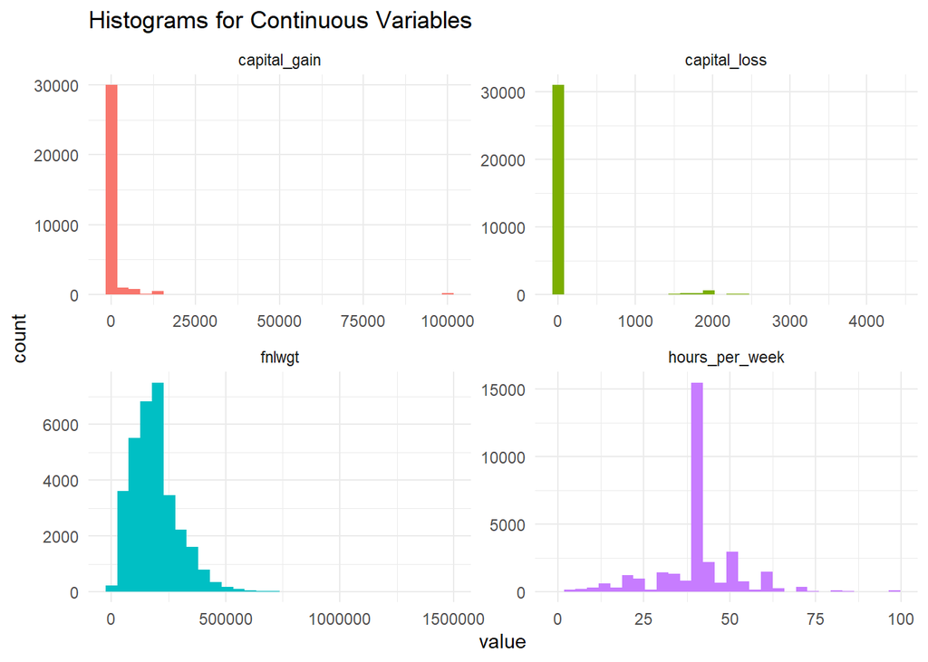

```r
# Create histograms for each variable using facet_wrap
ggplot(cont_long, aes(x = value, fill = variable)) +
  geom_histogram(position = "identity") +
  facet_wrap(~variable, scales = "free") +
  labs(title = "Histograms for Continuous Variables") +
  theme_minimal() +
  guides(fill = FALSE)
```

Once again, I see some skewness to keep in mind. However, I won’t do data transformations unless I see a case for it in the residuals plots.

# Fit a Logistic Regression Model

Now, I would like to explore how factors outside our control may influence our salary. In these data, the variables I see that would fall under this category are `age`, `race`, `sex`, `native_country`.

Null hypothesis: All coefficients in the equation take the value zero.

Alternative hypothesis: The model with the predictors under consideration is accurate and differs significantly from the null.

```r
# Summarize counts by race category
c_train %>%
  group_by(race) %>%
  summarise(count = n()) %>%
  arrange(count = n())
```

| race | count |
| --- | --- |
| Amer-Indian-Eskimo | 311 |
| Asian-Pac-Islander | 1039 |
| Black | 3124 |
| Other | 271 |
| White | 27815 |

```r
# Re-level `race` based on populations
c_train$race <- factor(c_train$race, levels = c("White",
                                                "Black",
                                                "Asian-Pac-Islander",
                                                "Amer-Indian-Eskimo",
                                                "Other"))
```

First, re-level the `race` category based on counts, setting the most prevalent group as the reference for model building.

```r
# Fit the null model
null_mod <- glm(income ~ 1,
                data = c_train,
              family = binomial)

# Fit the alternative model
alt_mod <- glm(income ~ age + race + sex + native_country,
              data = c_train,
              family = binomial)

summary(alt_mod)
```

```
##
## Call:
## glm(formula = income ~ age + race + sex + native_country, family = binomial,
##     data = c_train)
##
## Deviance Residuals:
##     Min       1Q   Median       3Q      Max
## -1.5061  -0.7967  -0.4461  -0.0002   3.7723
##
## Coefficients:
##                                            Estimate Std. Error z value Pr(>|z|)
## (Intercept)                              -1.823e+01  1.918e+02  -0.095  0.92428
## age18                                     7.206e-03  2.517e+02   0.000  0.99998
## age19                                     1.166e+01  1.918e+02   0.061  0.95153
## age20                                     2.400e-02  2.366e+02   0.000  0.99992
## age21                                     1.203e+01  1.918e+02   0.063  0.94998
## age22                                     1.343e+01  1.918e+02   0.070  0.94417
## age23                                     1.322e+01  1.918e+02   0.069  0.94506
## age24                                     1.423e+01  1.918e+02   0.074  0.94087
## age25                                     1.476e+01  1.918e+02   0.077  0.93864
## age26                                     1.500e+01  1.918e+02   0.078  0.93767
## age27                                     1.520e+01  1.918e+02   0.079  0.93683
## age28                                     1.563e+01  1.918e+02   0.081  0.93506
## age29                                     1.580e+01  1.918e+02   0.082  0.93436
## age30                                     1.602e+01  1.918e+02   0.084  0.93345
## age31                                     1.607e+01  1.918e+02   0.084  0.93322
## age32                                     1.618e+01  1.918e+02   0.084  0.93277
## age33                                     1.612e+01  1.918e+02   0.084  0.93301
## age34                                     1.641e+01  1.918e+02   0.086  0.93180
## age35                                     1.626e+01  1.918e+02   0.085  0.93245
## age36                                     1.654e+01  1.918e+02   0.086  0.93129
## age37                                     1.672e+01  1.918e+02   0.087  0.93053
## age38                                     1.675e+01  1.918e+02   0.087  0.93043
## age39                                     1.676e+01  1.918e+02   0.087  0.93036
## age40                                     1.678e+01  1.918e+02   0.087  0.93030
## age41                                     1.679e+01  1.918e+02   0.088  0.93026
## age42                                     1.678e+01  1.918e+02   0.087  0.93029
## age43                                     1.683e+01  1.918e+02   0.088  0.93008
## age44                                     1.696e+01  1.918e+02   0.088  0.92952
## age45                                     1.699e+01  1.918e+02   0.089  0.92943
```

[output cut: 203 more lines]

```
## native_countryThailand
## native_countryTrinadad&Tobago
## native_countryUnited-States
## native_countryVietnam                    *
## native_countryYugoslavia
## ---
## Signif. codes:  0 '***' 0.001 '**' 0.01 '*' 0.05 '.' 0.1 ' ' 1
##
## (Dispersion parameter for binomial family taken to be 1)
##
##     Null deviance: 35948  on 32559  degrees of freedom
## Residual deviance: 29603  on 32442  degrees of freedom
## AIC: 29839
##
## Number of Fisher Scoring iterations: 16
```

Age does not appear to be a significant predictor in the summary output, so let’s test if we should remove it (due to the principle of parsimony) with a Likelihood-Ratio Test (LRT).

```r
# Fit model without age
alt_mod2 <- glm(income ~ race + sex + native_country,
              data = c_train,
              family = binomial)

# Perform (LRT)
lrtest(alt_mod, alt_mod2)
```

|  | #Df | LogLik | Df | Chisq | Pr(>Chisq) |
| --- | --- | --- | --- | --- | --- |
| 1 | 118 | -14801.29 | NA | NA | NA |
| 2 | 46 | -16819.21 | -72 | 4035.838 | 0 |

The small p-value suggests the inclusion of `age` improves the model fit. Therefore we will keep `age` in the model for the analysis.

# Model Fit and Diagnostics

The logistic regression assumptions we need to check are: * Dependent variable must be binary (or ordinal). This assumption is met. * Observations must be independent of each other. This assumption is met in the Census sampling design. * Must be little to no multicollinearity among independent variables (VIF test). This assumption is not met. See below for more information. * Linearity of independent variables and log odds (residuals plots). This assumption is partially met. See below for more information. * Large sample size. This assumption is met.

```r
# Check multicollinearity assumption
# VIF < 5 required to state no multicollinearity
vif(alt_mod)
```

```
##                                    age18
##                             3.424704e+07
##                                    age19
##                             2.561887e+07
##                                    age20
##                             4.119217e+07
##                                    age21
##                             2.590010e+07
##                                    age22
##                             2.747977e+07
##                                    age23
##                             3.139199e+07
##                                    age24
##                             2.863538e+07
##                                    age25
##                             3.013753e+07
##                                    age26
##                             2.818041e+07
##                                    age27
##                             2.992817e+07
##                                    age28
##                             3.104377e+07
##                                    age29
##                             2.915985e+07
##                                    age30
##                             3.083477e+07
##                                    age31
##                             3.177462e+07
##                                    age32
##                             2.964890e+07
##                                    age33
##                             3.132231e+07
##                                    age34
##                             3.170506e+07
##                                    age35
##                             3.135711e+07
##                                    age36
##                             3.212230e+07
##                                    age37
##                             3.073024e+07
```

[output cut: 179 more lines]

```
##                             6.309357e+00
##                      native_countrySouth
##                             8.888053e+00
##                     native_countryTaiwan
##                             6.268614e+00
##                   native_countryThailand
##                             8.613571e+00
##            native_countryTrinadad&Tobago
##                             1.167643e+01
##              native_countryUnited-States
##                             3.418833e+01
##                    native_countryVietnam
##                             1.708400e+01
##                 native_countryYugoslavia
##                             5.261268e+00
```

We can see `race` and `native_country` showing many instances of greater than 5 for the variance inflation factor, so our model as-is violates the multicollinearity assumption. Two ways I could try to address this are adding a `race:native_country` interaction term, or removing `native_country` altogether. I’m not going to do this however, because this model is intended to gain insights rather than make accurate predictions.

```r
# If there are NA's in the model coefficient estimates, I could use correlation as a proxy for VIF:

# Create a correlation plot for all variables
# For factor variables, model.matrix codes non-numeric variables
# (cor_plot <- model.matrix(~ race + sex + native_country + race:native_country,
#                           data = c_train[, c(9, 10, 14)]) %>%
#    cor(use = "pairwise.complete.obs") %>%
#    ggcorrplot(type = "upper" ,lab = TRUE))

# Filter for correlations greater than 0.9
# (correlated_vars <- filter(cor_plot$data, value > 0.9))
```

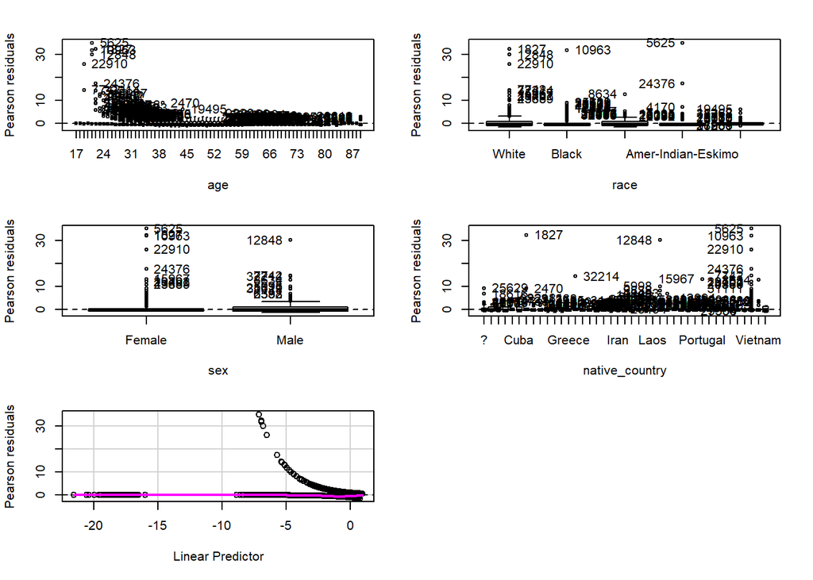

```r
# Check for linearity between each predictor and the log odds of the response
residualPlots(alt_mod)
```

We are seeing data points not entirely centered around zero with the model. I am not fully confident in linearity of the relationship between each predictor and the log-odds of the response variable. Since all our variables are categorical (age is typically used as a categorical variable in regression modeling), I can’t do data transformations, so I will accept what I’m seeing.

I see some outlier data points as well. Let’s look further into the outliers with an outlier test:

```r
# Perform outlier test
outlierTest(alt_mod)
```

```
## No Studentized residuals with Bonferroni p < 0.05
## Largest |rstudent|:
##      rstudent unadjusted p-value Bonferroni p
## 5625 3.820968         0.00013293           NA
```

Based on a small p-value, let’s continue exploration of outliers.

We need to look at summary statistics for: * Studentized residuals to view outliers * Hat values to view data with high leverage * Cook’s distance to view data with high influence

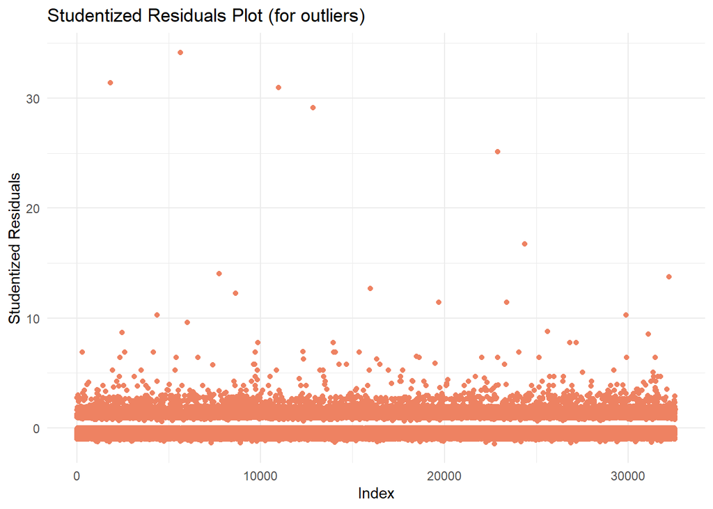

```r
# Studentized residuals
sr <- studres(alt_mod)

# Create a data frame
resid_df <- data.frame(index = seq_along(sr), stdresiduals = sr)

# Plot
ggplot(resid_df, aes(x = index, y = stdresiduals)) +
  geom_point(col = "salmon2") +
  labs(title = "Studentized Residuals Plot (for outliers)") +
  labs(x = "Index", y = "Studentized Residuals") +
  theme_minimal()
```

There appear to be five strong outlier data points, and a good number of less strong outliers based on the studentized residuals.

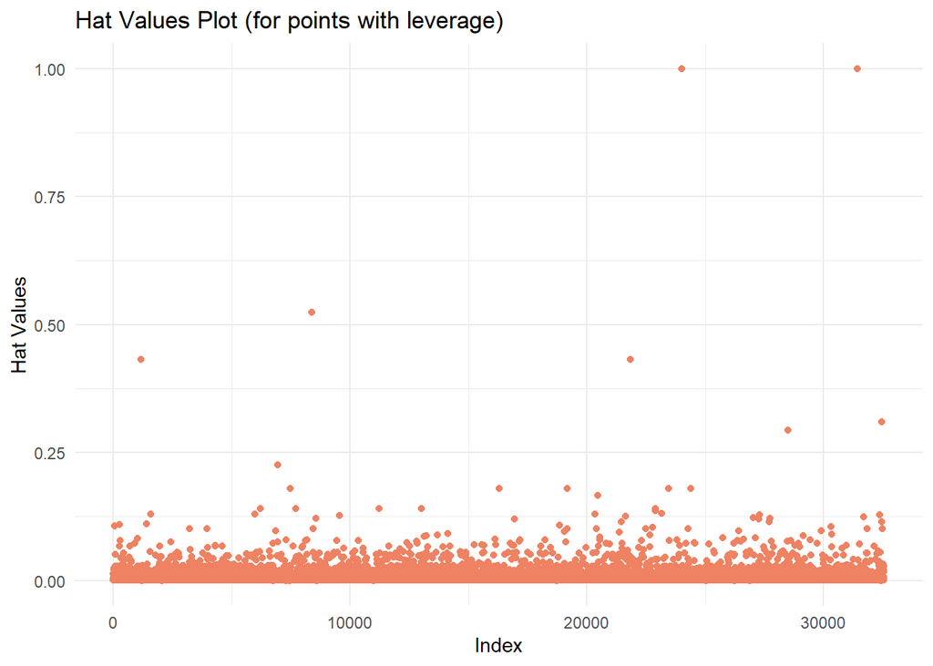

```r
# Hat values
hat <- hatvalues(alt_mod)

# Create a ggplot for hat values plot
ggplot(data.frame(index = seq_along(hat), hat_values = hat),
       aes(x = index, y = hat_values)) +
  geom_point(col = "salmon2") +
  labs(title = "Hat Values Plot (for points with leverage)",
       x = "Index", y = "Hat Values") +
  theme_minimal()
```

There appear to be many data points with leverage, two of which are ~1.

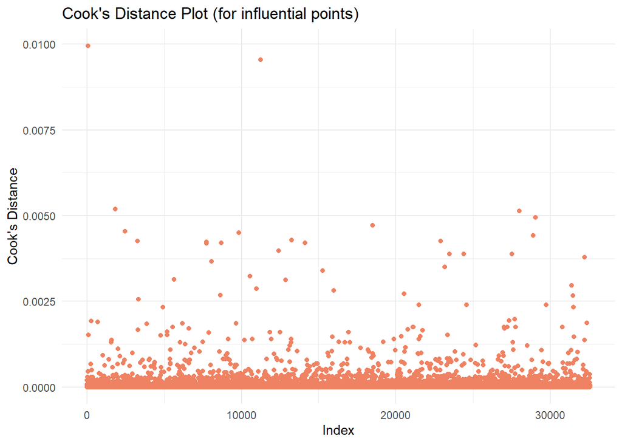

```r
# Cook's distance
cooks_dist <- cooks.distance(alt_mod)

# ggplot for Cook's distance plot
ggplot(data.frame(index = seq_along(cooks_dist), cooks_distance = cooks_dist),
       aes(x = index, y = cooks_distance)) +
  geom_point(col = "salmon2") +
  labs(title = "Cook's Distance Plot (for influential points)") +
  labs(x = "Index", y = "Cook's Distance") +
  theme_minimal()
```

There appear to be even more data points that are influential to the model.

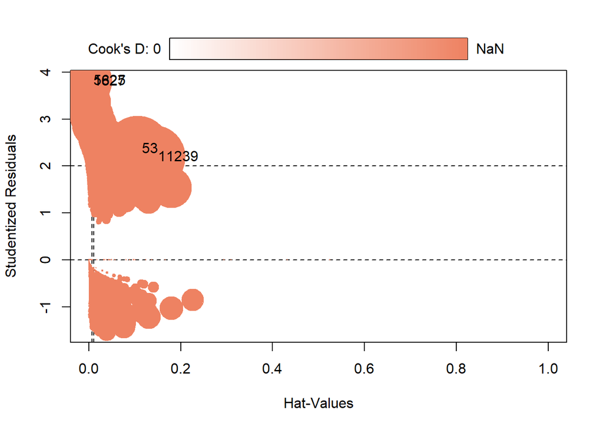

|  | StudRes | Hat | CookD |
| --- | --- | --- | --- |
| 53 | 2.371368 | 0.1061246594 | 0.009953543 |
| 1827 | 3.809816 | 0.0005849472 | 0.005181577 |
| 5625 | 3.820968 | 0.0003007333 | 0.003134815 |
| 11239 | 2.197973 | 0.1409026095 | 0.009546941 |
| 24027 | NaN | 1.0000000000 | NaN |
| 31432 | NaN | 1.0000000000 | NaN |

```r
# Overall influence plot
influencePlot(alt_mod,
              col = "salmon2",
              fill.col = "salmon2",
              fill.alpha = 0.5)
```

This overall influence plot identifies unusual observations by plotting studentized residuals against hat-values, with the size of circle is proportional to Cook’s distance. There are six data points I would need to remove had this model been intended for prediction. For the purpose of data analysis, I am going to consider this dataset representative of the population and I will not exclude any of these data points since it is a Census dataset.

```r
# Test model fit
hoslem.test(alt_mod$y, fitted(alt_mod))
```

```
##
##  Hosmer and Lemeshow goodness of fit (GOF) test
##
## data:  alt_mod$y, fitted(alt_mod)
## X-squared = 15.937, df = 8, p-value = 0.04329
```

```r
# big p-value means no significant difference between observed and predicted
#   values which would be a "good model fit"
```

Finally, I can test the model fit. With a p-value of < 0.05, I can say there is a significant difference between observed and predicted values which means we may not have a “good model fit”.

# Interpret the Model

```r
# Perform a Likelihood Ratio Test to test our hypothesis
lrtest(null_mod, alt_mod)
```

|  | #Df | LogLik | Df | Chisq | Pr(>Chisq) |
| --- | --- | --- | --- | --- | --- |
| 1 | 1 | -17973.76 | NA | NA | NA |
| 2 | 118 | -14801.29 | 117 | 6344.95 | 0 |

Returning to our hypothesis, we have evidence to reject the null and suggest age, race, sex, and native country are significant contributors to whether salary is <= or > $50k annually based on a p-value of essentially zero using a Likelihood Ratio test.

Now that we have gained some insight, let’s discuss the effect size (for logistic regression this is the odds ratio) of the `race` predictor variable.

```r
# Calculate multiplicative difference for Black racial group
exp(-0.7808)                              # Point estimate
```

```
## [1] 0.4580394
```

```r
exp(-0.7808 + c(-1, 1) * 1.96 * 0.06028)  # 95% C.I.
```

```
## [1] 0.4069973 0.5154829
```

```r
# 0.4580394
# 0.4069973, 0.5154829

# Calculate multiplicative difference for Asian-Pac-Islander racial group
exp(-0.03096)
```

```
## [1] 0.9695144
```

```r
exp(-0.03096 + c(-1, 1) * 1.96 * 0.1250)
```

```
## [1] 0.7588433 1.2386722
```

```r
# 0.9695144
# 0.7588433, 1.2386722

# Calculate multiplicative difference for Amer-Indian-Eskimo
exp(-0.9715)
```

```
## [1] 0.3785148
```

```r
exp(-0.9715 + c(-1, 1) * 1.96 * 0.1857)
```

```
## [1] 0.2630340 0.5446957
```

```r
# 0.3785148
# 0.2630340, 0.5446957

# Calculate multiplicative difference for Other
exp(-0.6154)
```

```
## [1] 0.5404247
```

```r
exp(-0.6154 + c(-1, 1) * 1.96 * 0.2299)
```

```
## [1] 0.3443819 0.8480667
```

```r
# 0.5404247
# 0.3443819, 0.8480667
```

Coefficient interpretations: The Other racial group’s odds of making more than $50k annually are exp(-0.6154) = 0.54x that of the White racial group. The 95% CI for the multiplicative difference (change in odds ratio) are exp(-0.6154 + c(-1, 1) * 1.96 * 0.2299) = [0.34, 0.85].

General logistic regression formula:
$$\text{logit}(p(x)) = \beta_0 + \beta_1 x_1 + \beta_2 x_2 + \ldots +
\beta_p x_p$$

where: - $p(x)$ is the probability of the event occurring. - $\beta_0$ is the intercept. - $\beta_1, \beta_2, \ldots, \beta_p$ are the coefficients for the predictor variables $x_1, x_2, \ldots, x_p$.

Probability that a male whose native country is the United States and is from the Other racial group makes > 50k is:
$$P(Salary >50k) = exp(-1.93942 + 1.151*1 + 0.05483*1 - 0.6154*1) =
0.26$$

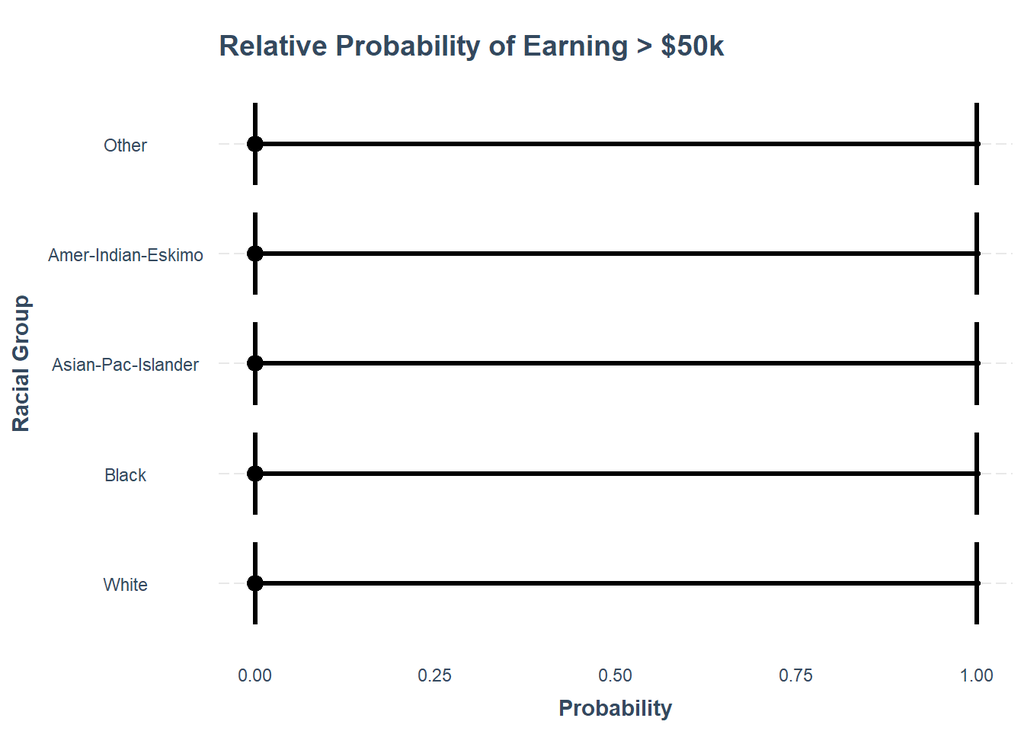

```r
# Visualize odds of income by race
effect_plot(alt_mod, pred = race, plot.points = TRUE,
            main.title = "Relative Probability of Earning > $50k",
            x.label = "Racial Group",
            y.label = "Probability") +
  coord_flip()
```

# Make Predictions

```r
# Filter out subjects who are 89 due to error:
c_test <- c_test %>%
  filter(age != 89)

# Make predictions
predictions <- predict(alt_mod, newdata = c_test, type = "response")
predictions <- ifelse(predictions < 0.265, "<=50K", ">50K")

# Evaluate accuracy
caret::confusionMatrix(as.factor(predictions), c_test$income)
```

```
## Confusion Matrix and Statistics
##
##           Reference
## Prediction <=50K >50K
##      <=50K  8133  925
##      >50K   4300 2921
##
##                Accuracy : 0.679
##                  95% CI : (0.6718, 0.6862)
##     No Information Rate : 0.7637
##     P-Value [Acc > NIR] : 1
##
##                   Kappa : 0.3174
##
##  Mcnemar's Test P-Value : <2e-16
##
##             Sensitivity : 0.6541
##             Specificity : 0.7595
##          Pos Pred Value : 0.8979
##          Neg Pred Value : 0.4045
##              Prevalence : 0.7637
##          Detection Rate : 0.4996
##    Detection Prevalence : 0.5564
##       Balanced Accuracy : 0.7068
##
##        'Positive' Class : <=50K
##
```

# Conclusion

Rather than being a great predictive model, our model serves to give us some insights into how factors we cannot control play into what our salary may be.

# Appendix

```r
knitr::opts_chunk$set(echo = TRUE)
knitr::opts_knit$set(root.dir = "C:/Users/james/OneDrive/Documents/School/Past Courses/ST 595/Three Projects/Project 3")
library(tidyverse)
library(ggdist)
library(MASS)
library(ggcorrplot)
library(car)
library(caret)
library(faraway)
library(jtools)
library(lmtest)
library(ResourceSelection)
# Read in census data
c_train <- read_csv("adult.csv")
c_test <- read_csv("adult.test.csv")
# Convert character columns to factor type
c_train <- c_train %>%
  mutate(
    age = as.factor(age),
    workclass = as.factor(workclass),
    education = as.factor(education),
    education_yrs = as.factor(education_yrs),
    marital_status = as.factor(marital_status),
    occupation = as.factor(occupation),
    relationship = as.factor(relationship),
    race = as.factor(race),
    sex = as.factor(sex),
    native_country = as.factor(native_country),
    income = as.factor(income)
  )

glimpse(c_train)

c_test <- c_test %>%
  mutate(
    age = as.factor(age),
    workclass = as.factor(workclass),
    education = as.factor(education),
    education_yrs = as.factor(education_yrs),
    marital_status = as.factor(marital_status),
    occupation = as.factor(occupation),
    relationship = as.factor(relationship),
    race = as.factor(race),
    sex = as.factor(sex),
    native_country = as.factor(native_country),
    income = as.factor(income)
  )

glimpse(c_test)
# Check for NA values
c_train %>%
  summarise_all(~sum(is.na(.)))

c_test %>%
  summarise_all(~sum(is.na(.)))
# Plot response variable distribution
ggplot(c_train, aes(x = income, fill = income)) +
  geom_bar(alpha = 0.75) +
  labs(title = "Income Distribution", x = "Income Category", y = "Count") +
  theme_minimal()
# Examine data
# Specify categorical columns
cat_columns <- list(
  c("occupation", "relationship", "race", "sex"),
  c("native_country", "age", "workclass", "education"),
  c("education_yrs", "marital_status")
)

# Function to create histograms
create_histograms <- function(cat_data, title) {
  cat_long <- gather(c_train, key = "variable", value = "value", cat_data)

  ggplot(cat_long, aes(x = value, fill = variable)) +
    geom_histogram(position = "identity", stat = "count") +
    facet_wrap(~variable, scales = "free") +
    labs(title = title) +
    theme_minimal() +
    scale_x_discrete(guide = guide_axis(angle = 45)) +
    guides(fill = FALSE)
}

# Create histograms for each set of categorical columns
for (i in seq_along(cat_columns)) {
  title <- paste("Histograms for Categorical Variables (", i, " of 3)", sep = "")
  plot_output <- create_histograms(cat_columns[[i]], title)
  print(plot_output)
}
# Examine the independent variables
cont_columns <- c("fnlwgt", "capital_gain", "capital_loss", "hours_per_week")

# Reshape the data to long format using tidyr
cont_long <- gather(c_train, key = "variable", value = "value", cont_columns)

# Create histograms for each variable using facet_wrap
ggplot(cont_long, aes(x = value, fill = variable)) +
  geom_histogram(position = "identity") +
  facet_wrap(~variable, scales = "free") +
  labs(title = "Histograms for Continuous Variables") +
  theme_minimal() +
  guides(fill = FALSE)
# Summarize counts by race category
c_train %>%
  group_by(race) %>%
  summarise(count = n()) %>%
  arrange(count = n())

# Re-level `race` based on populations
c_train$race <- factor(c_train$race, levels = c("White",
                                                "Black",
                                                "Asian-Pac-Islander",
                                                "Amer-Indian-Eskimo",
                                                "Other"))
# Fit the null model
null_mod <- glm(income ~ 1,
                data = c_train,
              family = binomial)

# Fit the alternative model
alt_mod <- glm(income ~ age + race + sex + native_country,
              data = c_train,
              family = binomial)

summary(alt_mod)
# Fit model without age
alt_mod2 <- glm(income ~ race + sex + native_country,
              data = c_train,
              family = binomial)

# Perform (LRT)
lrtest(alt_mod, alt_mod2)
# Check multicollinearity assumption
# VIF < 5 required to state no multicollinearity
vif(alt_mod)
# If there are NA's in the model coefficient estimates, I could use correlation as a proxy for VIF:

# Create a correlation plot for all variables
# For factor variables, model.matrix codes non-numeric variables
# (cor_plot <- model.matrix(~ race + sex + native_country + race:native_country,
#                           data = c_train[, c(9, 10, 14)]) %>%
#    cor(use = "pairwise.complete.obs") %>%
#    ggcorrplot(type = "upper" ,lab = TRUE))

# Filter for correlations greater than 0.9
# (correlated_vars <- filter(cor_plot$data, value > 0.9))
# Check for linearity between each predictor and the log odds of the response
residualPlots(alt_mod)
# Perform outlier test
outlierTest(alt_mod)
# Studentized residuals
sr <- studres(alt_mod)

# Create a data frame
resid_df <- data.frame(index = seq_along(sr), stdresiduals = sr)

# Plot
ggplot(resid_df, aes(x = index, y = stdresiduals)) +
  geom_point(col = "salmon2") +
  labs(title = "Studentized Residuals Plot (for outliers)") +
  labs(x = "Index", y = "Studentized Residuals") +
  theme_minimal()
# Hat values
hat <- hatvalues(alt_mod)

# Create a ggplot for hat values plot
ggplot(data.frame(index = seq_along(hat), hat_values = hat),
       aes(x = index, y = hat_values)) +
  geom_point(col = "salmon2") +
  labs(title = "Hat Values Plot (for points with leverage)",
       x = "Index", y = "Hat Values") +
  theme_minimal()
# Cook's distance
cooks_dist <- cooks.distance(alt_mod)

# ggplot for Cook's distance plot
ggplot(data.frame(index = seq_along(cooks_dist), cooks_distance = cooks_dist),
       aes(x = index, y = cooks_distance)) +
  geom_point(col = "salmon2") +
  labs(title = "Cook's Distance Plot (for influential points)") +
  labs(x = "Index", y = "Cook's Distance") +
  theme_minimal()
# Overall influence plot
influencePlot(alt_mod,
              col = "salmon2",
              fill.col = "salmon2",
              fill.alpha = 0.5)
# Test model fit
hoslem.test(alt_mod$y, fitted(alt_mod))

# big p-value means no significant difference between observed and predicted
#   values which would be a "good model fit"
# Perform a Likelihood Ratio Test to test our hypothesis
lrtest(null_mod, alt_mod)
# Calculate multiplicative difference for Black racial group
exp(-0.7808)                              # Point estimate
exp(-0.7808 + c(-1, 1) * 1.96 * 0.06028)  # 95% C.I.
# 0.4580394
# 0.4069973, 0.5154829

# Calculate multiplicative difference for Asian-Pac-Islander racial group
exp(-0.03096)
exp(-0.03096 + c(-1, 1) * 1.96 * 0.1250)
# 0.9695144
# 0.7588433, 1.2386722

# Calculate multiplicative difference for Amer-Indian-Eskimo
exp(-0.9715)
exp(-0.9715 + c(-1, 1) * 1.96 * 0.1857)
# 0.3785148
# 0.2630340, 0.5446957

# Calculate multiplicative difference for Other
exp(-0.6154)
exp(-0.6154 + c(-1, 1) * 1.96 * 0.2299)
# 0.5404247
# 0.3443819, 0.8480667
# Visualize odds of income by race
effect_plot(alt_mod, pred = race, plot.points = TRUE,
            main.title = "Relative Probability of Earning > $50k",
            x.label = "Racial Group",
            y.label = "Probability") +
  coord_flip()
# Filter out subjects who are 89 due to error:
c_test <- c_test %>%
  filter(age != 89)

# Make predictions
predictions <- predict(alt_mod, newdata = c_test, type = "response")
predictions <- ifelse(predictions < 0.265, "<=50K", ">50K")

# Evaluate accuracy
caret::confusionMatrix(as.factor(predictions), c_test$income)
```